# Hierachal computational modelling - FLARe

# Introduction

Lab book for analyses using hierachal computational modelling to identify paramters that define the best model of learning as it applies to fear conditioning acquisition and extinction using FLARe fear conditioning data. Long abstract, justification and analysis plan found in prelim manuscript here

In short:

## Impact and relevance

```
Evidence from both human (Richter et al., 2012) and rodent (Galatzer-Levy, Bonanno, Bush, & LeDoux, 2013) studies suggest that trajectories of how we learn and extinguish fear differ between individuals. Different trajectories of fear and extinction have also been found using fear conditioning studi…

Identifying parameters that predict individual trajectories of fear learning and extinction will enable us to harness fear conditioning data more effectively to aid in understanding mechanisms underlying the development of and treatment for anxiety disorders. With more accurate models of these proce…
```

## Useful references

[Sutton and Barto Reinforcement Learning](http://incompleteideas.net/book/RLbook2018.pdf) - Textbook on reinforcement learning  
[Anxiety promotes memory for mood-congruent faces but does not alter loss aversion (Charpentier…Robinson, 2015)](https://www.nature.com/articles/srep24746.pdf) - Good example of a sensitivity learning parameter  
[Hypotheses About the Relationship of Cognition With Psychopathology Should be Tested by Embedding Them Into Empirical Priors (Moutoussist et al., 2018)](https://www.frontiersin.org/articles/10.3389/fpsyg.2018.02504/full) - Including variables of interest (e.g. anxiety) in the model

Toby Wise has just submitted an aversive learning paper incorporating beta probability distributions in the best model for uncertain learning paramters etc.

A copy of this is here

## Analysis plan

1. Define set of a priori models moving from simple to more complex
   - Some paramters to include:
     - Rate of learning (sometimes with punishment reinforcement)
     - Sensitivity to punishment
     - Pre-existing anxiety
     - SES? Gender?
2. Run each model and compare fit in FLARe pre TEDS data
   - Use Log likelihood and BIC etc.
3. Select best fitting model
4. Extract individual data for learning parameters from this model and see what factors best predict it
   - Anxiety (if anxiety isnt best as part of the model)
   - Interpretation biases
   - Tolerance of uncertanty
   - Cognitive emotional control
   - emotional attentional control
   - SES?
   - Gender?
5. Run all models again in FLARe TEDS
   - Decide if the same model best fits the data again.
   - See if we get similar results from the parameter prediction

Will use a combination of `R.Version(3.5.1)`, `RStan (Version 2.18.2, GitRev: 2e1f913d3ca3)` and `hBayesDM package in R (3.5.1)` [Ahn, W.-Y., Haines, N., & Zhang, L. (2017). Revealing neuro-computational mechanisms of reinforcement learning and decision-making with the hBayesDM package. Computational Psychiatry, 1, 24-57.](https://doi.org/10.1162/CPSY_a_00), which uses RStan

# Analyses

## Preliminary

### Set up

These use Alex Pikes RStan script with minor modification to make it punishment only to see if it runs. Testing that the approach works with the current data set up etc.

### Try RStan

See if the basic punishment only learning model for the CS+ and CS- works with the FLARe master data

#### Run the 8schools check

From the [rstan github](https://github.com/stan-dev/rstan/wiki/RStan-Getting-Started)

This is to check that all is compiling and working and to give and idea of data format etc.

#### Adjust dataframe

load in the week 1 app and lab data for FLARe pilot, TRT and headphones studies. Make it long form.

Try with acquisition data first. This is formatted with no column names, with no missing data.

Derive the n parameter for both files and check these match

```r
stanname='punish_only.stan'
minus_name <- 'bayes_acq_minus.csv'
plus_name <- "bayes_acq_plus.csv"
stanfile <- file.path(scriptdir, stanname)
minusfile <- file.path(datadir,minus_name)
plusfile <- file.path(datadir,plus_name)
minus <- fread(minusfile,data.table=F)
plus <-fread(plusfile,data.table=F)
nacqm <- dim(minus)[1]
nacqp <- dim(plus)[1]
## check that these match and create nsub variable for RStan
if (nacqm == nacqp) {
  print('subject number match')
  nsub <- nacqm

  print(paste('nsub set to',nsub,sep=" "))
} else {
  print('WARNING: subject number does not match. Check master dataset')
}
```

```
[1] "subject number match"
[1] "nsub set to 342"
```

```r
# check the file format is ok
minus[1:2,]
```

```
  V1 V2 V3 V4 V5 V6 V7 V8 V9 V10 V11 V12
1  5  4  3  1  2  2  1  2  3   2   3   2
2  8  8  1  5  4  3  2  1  1   1   1   1
```

```r
plus[1:2,]
```

```
  V1 V2 V3 V4 V5 V6 V7 V8 V9 V10 V11 V12
1  5  6  7  4  7  7  6  7  2   8   7   8
2  1  9  9  5  8  8  9  9  9   8   9   8
```

```r
# create the n trials variable for RStan
ntrials <- 12
```

The expectancy rating datasets look like they are formatted fine and ntrials and nsub variables should exist.

##### Create scream data

Need to go back to stage zero and keep scream yes/no as a variable. For now to see if this runs create simulated version for the CS+. CS- will remain the same.

```r
screamMinus <- matrix(0L,nrow=nsub, ncol=ntrials)
# Initialise plus dataset in the same way, but make the first trial 1 for everyone, then add 8 additional random 1's per person. Do this in four random patterns to mimic the real data
sc1 <- c(1,1,0,1,0,0,1,1,1,1,1)
sc2 <- c(0,1,1,1,0,0,1,1,1,1,1)
sc3 <- c(1,1,1,0,1,0,1,0,1,1,1)
sc4 <- c(1,0,1,1,0,0,1,1,1,1,1)
screamPlus <- matrix(0L,nrow=nsub, ncol=ntrials)
screamPlus[,1] <- 1
# for (n in 1:dim(screamPlus)[1]) {
#   print(n)
#   screamPlus[n,2:12] <- sample(patts,1,replace=T)
# }
for (n in 1:dim(screamPlus)[1]) {

  a <- sample(c(1,4),1)

  if (a == 1) {
    screamPlus[n,2:12] <- sc1
  } else if (a == 2) {
    screamPlus[n,2:12] <- sc2
  } else if (a == 3){
    screamPlus[n,2:12] <- sc3
  } else {
    screamPlus[n,2:12] <- sc4
  }
}
```

##### make rating data binary

for now to see if stan runs using bernoulli-logit function make binary resposnes from expectancy i.e. >=4.5 ==1, <= 4.5 ==0.

```r
binarise <- function(x) {
  ifelse(x >= 4.5,1,0)
}
```

```r
minusb <- data.frame(apply(minus,2,function(x) binarise(x)))
plusb <- data.frame(apply(plus,2,function(x) binarise(x)))
```

#### Set up procedure to create and sync models.

This directs to my local machine here */Users/kirstin/Dropbox/SGDP/FLARe/FLARe_MASTER/Projects/Hierachal_modelling/Scripts* and is remotely linked to the github [repository here](https://github.com/klpurves/FLARe_Bayesian_hierarchical).

##### Make sure the most up to date stan file is in the remote repo

```bash
git pull Bayes_modelling
```

```
Already up to date.
```

##### check existing paramters

Unhash this if you want to check what the model looks like within the notebook.

```bash
stanname="punish_only.stan"
scriptdir="/Users/kirstin/Dropbox/SGDP/FLARe/FLARe_MASTER/Projects/Hierachal_modelling/Scripts"

#cat $scriptdir/$stanname
```

##### Make any changes

use echo to push these to the new file if you want to make changes from here.

```bash
## initialise bash directory and filename

stanname="punish_only.stan"
scriptdir="/Users/kirstin/Dropbox/SGDP/FLARe/FLARe_MASTER/Projects/Hierachal_modelling/Scripts"


#echo "<any changes here>" > $scriptdir/$stanname
```

#### Now try run stan

```r
flare_data<-list(ntrials=ntrials,nsub=nsub,includeTrial = rep(1,ntrials), screamPlus=t(screamPlus),screamMinus=t(screamMinus),
                 ratingPlus=t(plusb),ratingMinus=t(minusb))
#flare_fit <- stan(file = stanfile, data = flare_data, iter=chain_iter, chains = chain_n) #add working dir?
#save(flare_fit, file=file.path(datadir,'flare_fit_test'))
#traceplot(flare_fit,'lp__')
# extract fit data
#summary_flare<- summary(flare_fit)
# extract model summary data
#flare_loglike<- extract_log_lik(flare_fit, parameter_name = "loglik", merge_chains = TRUE)
```

view the fit information

```r
#summary_flare
```

extract the loglikelihood using loo

```r
#loo(flare_loglike)
```

## Model attempt 1

### notes

Discussion with Vince Valton and Alex Pike about the best way to fit this model. As the observed outcomes (expectancy ratings) are non binary and are related to eachother (i.e. as you become more likely to select 9, you become less likely to select 1) we should consider each trial for each person for each stimulus as a constantly updating beta distribution. so you might see a pattern like this for the CS+ in acq for example.

```r
x <- seq(0, 1, length = 21)
dbeta(x, 1, 1)
```

```
 [1] 1 1 1 1 1 1 1 1 1 1 1 1 1 1 1 1 1 1 1 1 1
```

```r
pbeta(x, 1, 1)
```

```
 [1] 0.00 0.05 0.10 0.15 0.20 0.25 0.30 0.35 0.40 0.45 0.50 0.55 0.60 0.65 0.70 0.75 0.80 0.85 0.90 0.95
[21] 1.00
```

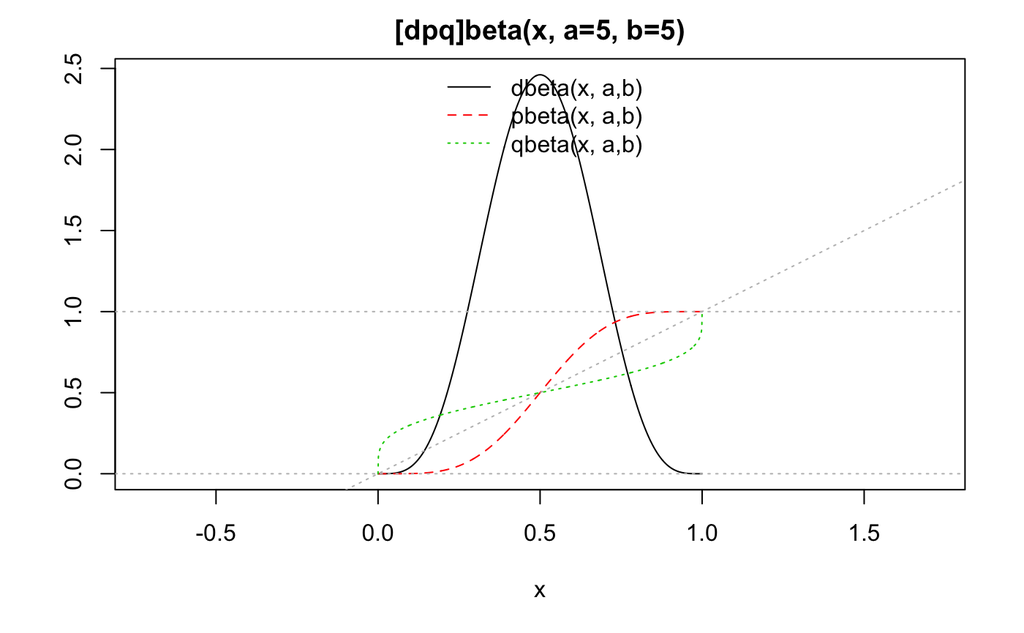

```r
## Visualization, including limit cases:
pl.beta <- function(a,b, asp = if(isLim) 1, ylim = if(isLim) c(0,1.1)) {
  if(isLim <- a == 0 || b == 0 || a == Inf || b == Inf) {
    eps <- 1e-10
    x <- c(0, eps, (1:7)/16, 1/2+c(-eps,0,eps), (9:15)/16, 1-eps, 1)
  } else {
    x <- seq(0, 1, length = 1025)
  }
  fx <- cbind(dbeta(x, a,b), pbeta(x, a,b), qbeta(x, a,b))
  f <- fx; f[fx == Inf] <- 1e100
  matplot(x, f, ylab="", type="l", ylim=ylim, asp=asp,
          main = sprintf("[dpq]beta(x, a=%g, b=%g)", a,b))
  abline(0,1,     col="gray", lty=3)
  abline(h = 0:1, col="gray", lty=3)
  legend("top", paste0(c("d","p","q"), "beta(x, a,b)"),
         col=1:3, lty=1:3, bty = "n")
  invisible(cbind(x, fx))
}
## change alpha
pl.beta(5, 5,asp=0.5)
```

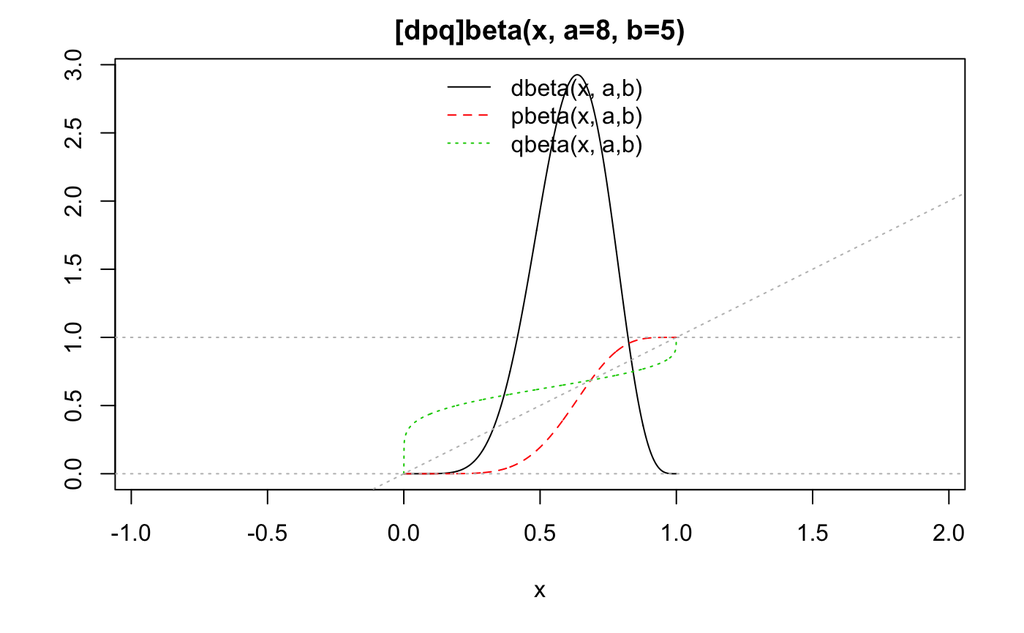

```r
pl.beta(8, 5,asp=0.5)
```

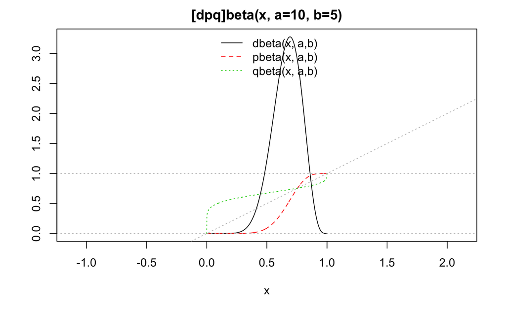

```r
pl.beta(10, 5,asp=0.5)
```

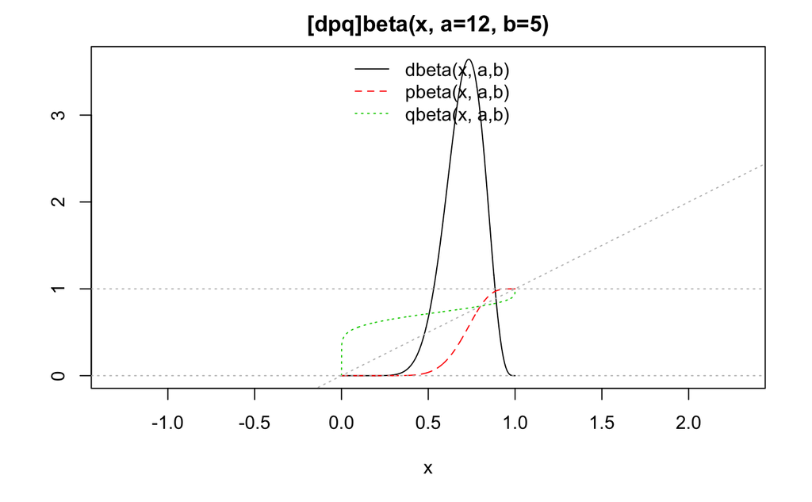

```r
pl.beta(12, 5,asp=0.5)
```

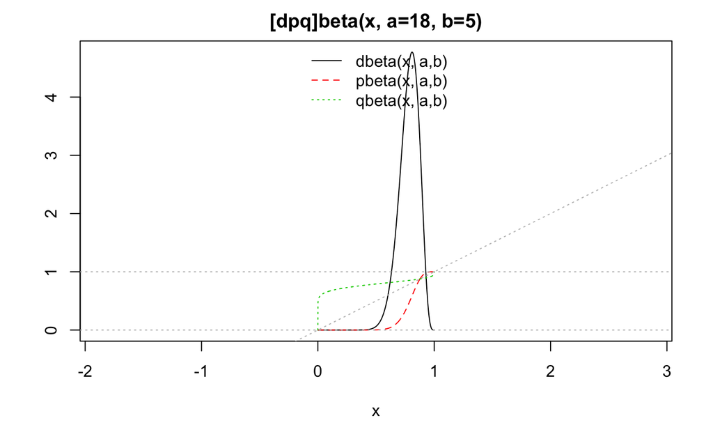

```r
pl.beta(18, 5,asp=0.5)
```

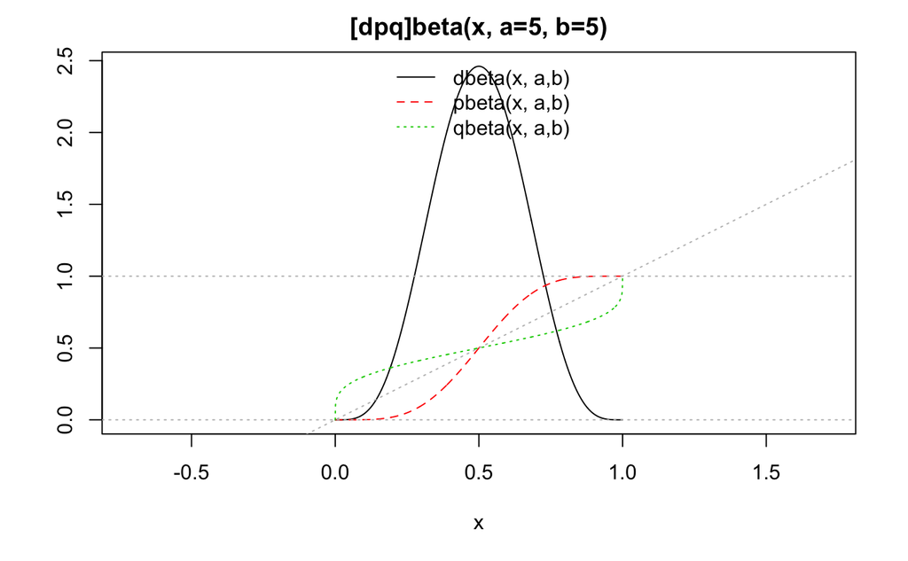

```r
## change beta
pl.beta(5, 5,asp=0.5)
```

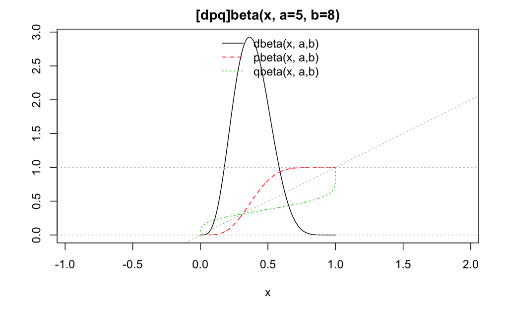

```r
pl.beta(5, 8,asp=0.5)
```

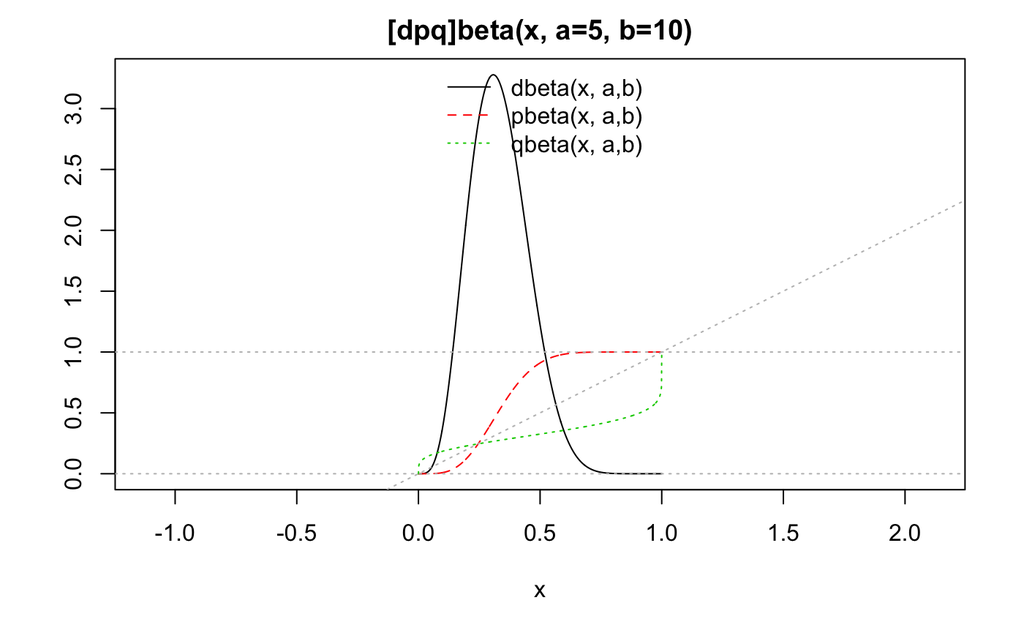

```r
pl.beta(5, 10,asp=0.5)
```

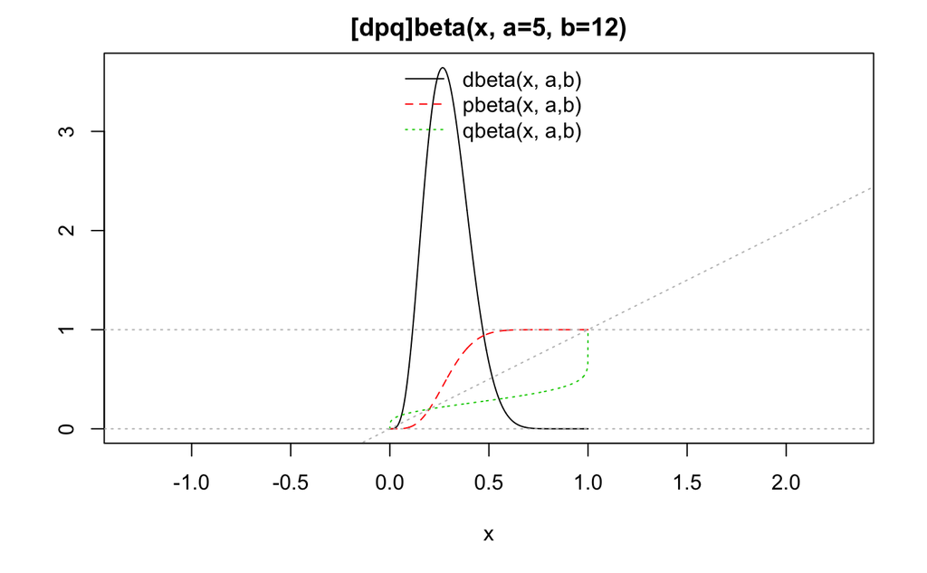

```r
pl.beta(5, 12,asp=0.5)
```

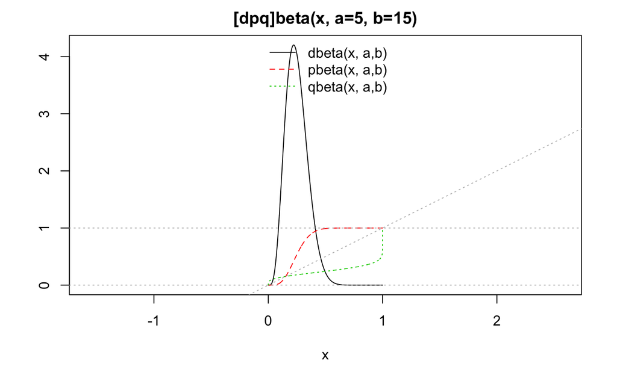

```r
pl.beta(5, 15,asp=0.5)
```

### rescale data

rescale the 1-9 expectancy values to be on a 0-1 scale.

```r
library(scales)
# rescale and flip so that we are effectively rating the expectation that they WILL NOT hear a scream to match stan
minus_scaled <- data.frame(apply(minus,2,function(x) 1-rescale(x, to=c(0.00001,0.99999))))
plus_scaled <- data.frame(apply(plus,2,function(x) 1-rescale(x, to=c(0.00001,0.99999))))
```

### create proportion screams data

```r
No_scream_p <- rep(3,nsub)
No_scream_m <- rep(12,nsub)
```

### run Alex Pike’s stan script for non scaled beta model.

here we try to estimate the alpha paramter of the beta distribution per trial per person per stimulus. (i.e. you have two sufficient paramters for each beta dist, the alpha and beta. we want to estimate the alpha - ).

Eventually we will scale these by the actual ‘value’ of the scream for each person per trial.

Using data loaded in from preliminary tests above.

so this is a beta value per person (assuming the underlying process for the plus and minus are the same)

```r
summary_flare
```

[output not shown]

[output cut: 297 more lines]

```
  beta[128] 1.657272e-01  0.03208093 1.079238e-01 1.429433e-01 1.648445e-01 1.872735e-01 2.299027e-01
  beta[129] 2.061802e-01  0.04854847 1.161287e-01 1.715812e-01 2.038727e-01 2.360823e-01 3.205724e-01
  beta[130] 2.435765e+00  0.54406693 1.522633e+00 2.060080e+00 2.414167e+00 2.775607e+00 3.602446e+00
  beta[131] 2.524028e-01  0.04883489 1.681386e-01 2.185739e-01 2.484188e-01 2.834718e-01 3.607886e-01
  beta[132] 2.264172e-01  0.04762502 1.479142e-01 1.913531e-01 2.215685e-01 2.597891e-01 3.325868e-01
  beta[133] 9.614597e-01  0.24560658 5.316167e-01 7.832204e-01 9.350017e-01 1.113398e+00 1.471532e+00
  beta[134] 2.042529e-01  0.04513693 1.276415e-01 1.722559e-01 2.014474e-01 2.304210e-01 2.949844e-01
  beta[135] 4.096911e-01  0.10609311 2.271717e-01 3.423660e-01 4.027487e-01 4.607007e-01 6.469477e-01
  beta[136] 1.690294e-01  0.03611594 1.126358e-01 1.424407e-01 1.668403e-01 1.937378e-01 2.447041e-01
  beta[137] 3.270085e-01  0.06364495 2.197491e-01 2.825513e-01 3.220184e-01 3.694617e-01 4.591856e-01
  beta[138] 1.679861e-01  0.03539361 1.061883e-01 1.438703e-01 1.668997e-01 1.914563e-01 2.395233e-01
  beta[139] 2.059845e-01  0.03947314 1.320499e-01 1.776895e-01 2.026403e-01 2.330626e-01 2.847352e-01
  beta[140] 2.238517e-01  0.04638561 1.425217e-01 1.932812e-01 2.211616e-01 2.505357e-01 3.316328e-01
  beta[141] 4.046631e-01  0.09339264 2.445258e-01 3.403807e-01 3.970018e-01 4.567651e-01 5.996442e-01
  beta[142] 1.611432e-01  0.03637527 9.462118e-02 1.369854e-01 1.583338e-01 1.844647e-01 2.346384e-01
```

# Push any updates to github

##### Any push the updates to github

Unhash the series below if you made any changes.

```bash
## initialise bash directory and filename
stanname="punish_only.stan"
scriptdir="/Users/kirstin/Dropbox/SGDP/FLARe/FLARe_MASTER/Projects/Hierachal_modelling/Scripts"


## stage
#git add $scriptdir/$stanname


## push

#git push Bayes_modelling
```